# Assignment 3: KNN Performance Improvements

Lizzy Presland

January 30, 2019

## Exploring and Preparing the Data

```r
bc_data = read.csv("wisc_bc_data.csv", header=TRUE)
```

Here’s some interesting summarizations of the data:

```r
head(bc_data)
```

```
##         id diagnosis radius_mean texture_mean perimeter_mean area_mean
## 1 87139402         B       12.32        12.39          78.85     464.1
## 2  8910251         B       10.60        18.95          69.28     346.4
## 3   905520         B       11.04        16.83          70.92     373.2
## 4   868871         B       11.28        13.39          73.00     384.8
## 5  9012568         B       15.19        13.21          97.65     711.8
## 6   906539         B       11.57        19.04          74.20     409.7
##   smoothness_mean compactness_mean concavity_mean points_mean
## 1         0.10280          0.06981        0.03987     0.03700
## 2         0.09688          0.11470        0.06387     0.02642
## 3         0.10770          0.07804        0.03046     0.02480
## 4         0.11640          0.11360        0.04635     0.04796
## 5         0.07963          0.06934        0.03393     0.02657
## 6         0.08546          0.07722        0.05485     0.01428
##   symmetry_mean dimension_mean radius_se texture_se perimeter_se area_se
```

[output cut: 34 more lines]

```r
summary(bc_data)
```

```
##        id            diagnosis  radius_mean      texture_mean
##  Min.   :     8670   B:357     Min.   : 6.981   Min.   : 9.71
##  1st Qu.:   869218   M:212     1st Qu.:11.700   1st Qu.:16.17
##  Median :   906024             Median :13.370   Median :18.84
##  Mean   : 30371831             Mean   :14.127   Mean   :19.29
##  3rd Qu.:  8813129             3rd Qu.:15.780   3rd Qu.:21.80
##  Max.   :911320502             Max.   :28.110   Max.   :39.28
##  perimeter_mean     area_mean      smoothness_mean   compactness_mean
##  Min.   : 43.79   Min.   : 143.5   Min.   :0.05263   Min.   :0.01938
##  1st Qu.: 75.17   1st Qu.: 420.3   1st Qu.:0.08637   1st Qu.:0.06492
##  Median : 86.24   Median : 551.1   Median :0.09587   Median :0.09263
##  Mean   : 91.97   Mean   : 654.9   Mean   :0.09636   Mean   :0.10434
##  3rd Qu.:104.10   3rd Qu.: 782.7   3rd Qu.:0.10530   3rd Qu.:0.13040
##  Max.   :188.50   Max.   :2501.0   Max.   :0.16340   Max.   :0.34540
##  concavity_mean     points_mean      symmetry_mean    dimension_mean
##  Min.   :0.00000   Min.   :0.00000   Min.   :0.1060   Min.   :0.04996
##  1st Qu.:0.02956   1st Qu.:0.02031   1st Qu.:0.1619   1st Qu.:0.05770
##  Median :0.06154   Median :0.03350   Median :0.1792   Median :0.06154
##  Mean   :0.08880   Mean   :0.04892   Mean   :0.1812   Mean   :0.06280
##  3rd Qu.:0.13070   3rd Qu.:0.07400   3rd Qu.:0.1957   3rd Qu.:0.06612
##  Max.   :0.42680   Max.   :0.20120   Max.   :0.3040   Max.   :0.09744
##    radius_se        texture_se      perimeter_se       area_se
##  Min.   :0.1115   Min.   :0.3602   Min.   : 0.757   Min.   :  6.802
##  1st Qu.:0.2324   1st Qu.:0.8339   1st Qu.: 1.606   1st Qu.: 17.850
##  Median :0.3242   Median :1.1080   Median : 2.287   Median : 24.530
##  Mean   :0.4052   Mean   :1.2169   Mean   : 2.866   Mean   : 40.337
##  3rd Qu.:0.4789   3rd Qu.:1.4740   3rd Qu.: 3.357   3rd Qu.: 45.190
##  Max.   :2.8730   Max.   :4.8850   Max.   :21.980   Max.   :542.200
##  smoothness_se      compactness_se      concavity_se
##  Min.   :0.001713   Min.   :0.002252   Min.   :0.00000
##  1st Qu.:0.005169   1st Qu.:0.013080   1st Qu.:0.01509
##  Median :0.006380   Median :0.020450   Median :0.02589
##  Mean   :0.007041   Mean   :0.025478   Mean   :0.03189
##  3rd Qu.:0.008146   3rd Qu.:0.032450   3rd Qu.:0.04205
##  Max.   :0.031130   Max.   :0.135400   Max.   :0.39600
##    points_se         symmetry_se        dimension_se        radius_worst
##  Min.   :0.000000   Min.   :0.007882   Min.   :0.0008948   Min.   : 7.93
##  1st Qu.:0.007638   1st Qu.:0.015160   1st Qu.:0.0022480   1st Qu.:13.01
##  Median :0.010930   Median :0.018730   Median :0.0031870   Median :14.97
##  Mean   :0.011796   Mean   :0.020542   Mean   :0.0037949   Mean   :16.27
```

[output cut: 8 more lines]

```
##  Max.   :49.54   Max.   :251.20   Max.   :4254.0   Max.   :0.22260
##  compactness_worst concavity_worst   points_worst     symmetry_worst
##  Min.   :0.02729   Min.   :0.0000   Min.   :0.00000   Min.   :0.1565
##  1st Qu.:0.14720   1st Qu.:0.1145   1st Qu.:0.06493   1st Qu.:0.2504
##  Median :0.21190   Median :0.2267   Median :0.09993   Median :0.2822
##  Mean   :0.25427   Mean   :0.2722   Mean   :0.11461   Mean   :0.2901
##  3rd Qu.:0.33910   3rd Qu.:0.3829   3rd Qu.:0.16140   3rd Qu.:0.3179
##  Max.   :1.05800   Max.   :1.2520   Max.   :0.29100   Max.   :0.6638
##  dimension_worst
##  Min.   :0.05504
##  1st Qu.:0.07146
##  Median :0.08004
##  Mean   :0.08395
##  3rd Qu.:0.09208
##  Max.   :0.20750
```

We will exclude the patient identifier (in the first column of the dataframe); this is done for two reasons:

- The ID is not a feature of interest for our k-NN model.
- More importantly, it is very important to remove personal identifiers from sensitive datasets like this, so that the subject’s privacy may be respected.

```r
bc_data[1] <- NULL
```

The target variable is **Diagnosis Type**, now listed in column 1. There are two levels: Benign (**B**), and Malignant (**M**).

This column of data needs to be factorized, and we will rename the shorthand **B** and **M** labels to something more informative.

```r
bc_data$diagnosis <- as.factor(bc_data$diagnosis)
levels(bc_data$diagnosis)[levels(bc_data$diagnosis)=="B"] <- "benign"
levels(bc_data$diagnosis)[levels(bc_data$diagnosis)=="M"] <- "malignant"
summary(bc_data$diagnosis)
```

```
##    benign malignant
##       357       212
```

Now, the percentage occurance of malignant and benign diagnoses can be calculated.

```r
library(plyr)
summarize( bc_data, "Frequency"=count(bc_data$diagnosis), "Percentage"=100*count(bc_data$diagnosis)/nrow(bc_data))
```

```
##   Frequency.x Frequency.freq Percentage.x Percentage.freq
## 1      benign            357           NA        62.74165
## 2   malignant            212           NA        37.25835
```

```r
# A better method for percentages:
# round(prop.table(table(bc_data$diagnosis)) * 100, digits = 1)
# Better Method Implemented:
round(prop.table(table(bc_data$diagnosis)) * 100, digits = 1)
```

```
##
##    benign malignant
##      62.7      37.3
```

Summary of these 3 features:

```r
summary(bc_data$radius_mean)
```

```
##    Min. 1st Qu.  Median    Mean 3rd Qu.    Max.
##   6.981  11.700  13.370  14.127  15.780  28.110
```

```r
summary(bc_data$area_mean)
```

```
##    Min. 1st Qu.  Median    Mean 3rd Qu.    Max.
##   143.5   420.3   551.1   654.9   782.7  2501.0
```

```r
summary(bc_data$smoothness_mean)
```

```
##    Min. 1st Qu.  Median    Mean 3rd Qu.    Max.
## 0.05263 0.08637 0.09587 0.09636 0.10530 0.16340
```

These features could be problematic because their numerical values are so disparate; if the model looks at numeric values with size being the largest determining factor across different features, then a feature that has larger units or values could be considered more significant or relevant to the outcome than others whose data spread/values are smaller (but is a more significant indicator for classification purposes).

For this reason, we want to normalize the data in a `[0, 1]` range.

## Transformation and Normalization

The normalize() function is defined as follows:

```r
normalize <- function(x){
  min <- min(x)
  range <- max(x) - min
  for (idx in 1:length(x)) {
    x[idx] <- (x[idx] - min) / range
  }
  return(x)
}
```

To test, we will create a simple vector:

```r
vals <- c(1, 2, 3, 4, 5)
vals <- normalize(vals)
vals
```

```
## [1] 0.00 0.25 0.50 0.75 1.00
```

Now that the function has been tested, normalize() will be applied to each numerical feature in the dataset. Because the first column of the dataset is a list of factors, the first column will be excluded.

```r
wbcd_norm <- as.data.frame(lapply(bc_data[-1], normalize))
```

Now, our data looks like this:

```r
head(wbcd_norm)
```

```
##   radius_mean texture_mean perimeter_mean  area_mean smoothness_mean
## 1   0.2526859    0.0906324      0.2422777 0.13599152       0.4529205
## 2   0.1712812    0.3124789      0.1761454 0.08606575       0.3994764
## 3   0.1921056    0.2407846      0.1874784 0.09743372       0.4971563
## 4   0.2034644    0.1244505      0.2018520 0.10235419       0.5756974
## 5   0.3885182    0.1183632      0.3721927 0.24106045       0.2437483
## 6   0.2171896    0.3155225      0.2101444 0.11291622       0.2963799
##   compactness_mean concavity_mean points_mean symmetry_mean dimension_mean
## 1        0.1546838     0.09341612  0.18389662     0.4540404      0.2019798
## 2        0.2923747     0.14964855  0.13131213     0.4353535      0.3148694
## 3        0.1799276     0.07136832  0.12326044     0.3303030      0.2830666
## 4        0.2890007     0.10859888  0.23836978     0.3590909      0.2266217
## 5        0.1532421     0.07949859  0.13205765     0.3338384      0.1154170
## 6        0.1774124     0.12851453  0.07097416     0.4904040      0.2676917
##    radius_se texture_se perimeter_se    area_se smoothness_se
```

[output cut: 34 more lines]

## Create the Datasets for Training

We will slice the data sets into two chunks for training and testing.

```r
wbcd_train <- wbcd_norm[1:469,]
wbcd_test <- wbcd_norm[470:569,]
```

Next, we will store the target variable for each corresponding dataset as a vector. Because the feature we wish to train the model on is not included in the normalized dataset we created, we must extract it from the original dataframe (and be careful to slice the dataframe with the same indeces we used to create the training & test datasets).

```r
wbcd_train_labels <- bc_data[1:469,]$diagnosis
wbcd_test_labels <- bc_data[470:569,]$diagnosis
```

## Training a Model on the Data

We will use the k-NN implementation from R’s `class` package. We import it like so:

```r
library(class)
```

If it is not previously installed, you may install the `class` package in R Studio by going to `Tools -> Install Packages...`, entering the package name `class` into the `Packages` prompt, and installing it to your default path.

##### Finding K

Without any other deciding factors influencing what K value is needed for the number of nearest neighbors evaluated, the best option is to use the square root of the training dataset size. In this case, because there are 469 units of observation included in our training dataset, I will initially use a K value of 22.

##### Create the Model

Here, the call to create the model is done:

```r
wbcd_test_pred <- knn(wbcd_train, wbcd_test, wbcd_train_labels, 22)
```

## Evaluating the Model’s Performance

Let’s look at the vectors for the test data’s target feature compared with the model’s prediction.

```r
prediction_table <- data.frame(wbcd_test_pred, wbcd_test_labels)
prediction_table
```

```
##     wbcd_test_pred wbcd_test_labels
## 1           benign           benign
## 2           benign           benign
## 3           benign           benign
## 4           benign           benign
## 5        malignant        malignant
## 6           benign           benign
## 7        malignant        malignant
## 8           benign           benign
## 9        malignant        malignant
## 10          benign           benign
## 11       malignant        malignant
## 12          benign           benign
## 13       malignant        malignant
## 14       malignant        malignant
```

[output cut: 86 more lines]

There are a few ways to evaluate the performance of the model; we primarily want to compare the test data’s true labels (contained in `wbcd_test_labels`) with the `knn()` call output (contained in `wbcd_test_pred`). It is also beneficial to look at the model’s overall accuracy; we shall do this second (after false positives and false negatives have been found).

#### Evaluating Accuracy using Chi-squared test of Prediction & Actual Vectors

Next, we examine the relationship between the two vectors using Pearson’s Chi-squared test.

The premise of a Chi-squared test is the null hypothesis: there is no relationship between the two variables. In this example, the null and alternative hypotheses can be stated as:

- Null Hypothesis: There is no relationship between the model’s prediction and the actual value of the target variable.
- Alternative Hypothesis: There is a statistically significant relationship between the model’s prediction and the actual value of the target variable; the model’s predicted value is a good prediction of the actual value.

In this test, we can only choose to reject the null hypothesis. We can make this determination from the Chi-square test’s p-value; a p-value that is less than our pre-determined significance level indicates that the null hypothesis can be rejected and there is a significant correlation between the two variables. For this example, we choose a significance level of 0.05.

```r
chisq_result <- chisq.test(wbcd_test_labels, wbcd_test_pred)
chisq_result
```

```
##
##  Pearson's Chi-squared test with Yates' continuity correction
##
## data:  wbcd_test_labels and wbcd_test_pred
## X-squared = 87.835, df = 1, p-value < 2.2e-16
```

Based on the Chi-squared test, this model is very accurate because the p-value is so small (less than `2.2e-16`).

#### Inspecting Type I and Type II Errors

Let us now examine the individual items whose predicted results were different from the actual value. We will examine two different possibilities:

- False positives (where prediction resulted in `malignant` label but the actual value was `benign`); this is a **Type I** error
- False negatives (where actual value was `malignant` but the prediction was `benign`); this is a **Type II** error

The code snippet below generates the dataframes for false positives and false negatives.

```r
false_positives <- data.frame(Index=integer(), Predicted=factor(), Actual=factor())
false_negatives <- data.frame(Index=integer(), Predicted=factor(), Actual=factor())
true_positives <- data.frame(Index=integer(), Predicted=factor(), Actual=factor())
true_negatives <- data.frame(Index=integer(), Predicted=factor(), Actual=factor())
for (idx in 1:100) {
  if (wbcd_test_pred[idx] == "malignant" && wbcd_test_labels[idx] == "benign") {
    new_row <- data.frame(Index=idx, Predicted=wbcd_test_pred[idx], Actual=wbcd_test_labels[idx])
    false_positives <- rbind(false_positives, new_row)
  }
  else if (wbcd_test_pred[idx] == "benign" && wbcd_test_labels[idx] == "malignant") {
    new_row <- data.frame(Index=idx, Predicted=wbcd_test_pred[idx], Actual=wbcd_test_labels[idx])
    false_negatives <- rbind(false_negatives, new_row)
  }
  else if (wbcd_test_pred[idx] == "benign") {
    new_row <- data.frame(Index=idx, Predicted=wbcd_test_pred[idx], Actual=wbcd_test_labels[idx])
    true_negatives <- rbind(true_negatives, new_row)
  } else {
    new_row <- data.frame(Index=idx, Predicted=wbcd_test_pred[idx], Actual=wbcd_test_labels[idx])
    true_positives <- rbind(true_positives, new_row)
  }
}
```

Now that we have two data frames reflecting our false positives and negatives, let’s examine these subsets:

```r
false_positives
```

```
## [1] Index     Predicted Actual
## <0 rows> (or 0-length row.names)
```

```r
false_negatives
```

```
##   Index Predicted    Actual
## 1    32    benign malignant
## 2    54    benign malignant
```

With the k-value of 22 (roughly `sqrt(N=469)`), 0 false positives were predicted, but 2 false negatives were generated.

In actual usage, false negatives are far more dangerous for cancer patients, because a malignant tumor was incorrectly assumed to be benign, and the patient will not receive further diagnosis steps and treatment options for a malignant disease.

#### Calculating Accuracy and Error of the Model

Lastly, we will examine overall accuracy of the model.

```r
error_rate <- (nrow(false_negatives)+nrow(false_positives)) / (nrow(false_negatives) + nrow(false_positives) + nrow(true_negatives) + nrow(true_positives))
accuracy <- 1 - error_rate
error_rate
```

```
## [1] 0.02
```

```r
accuracy
```

```
## [1] 0.98
```

These calculations indicate that the model is has an accuracy of 98% and has an error rate of 2%, which is reasonable.

#### Improving the Model

There may be a few ways of improving model performance; examining the model’s performance with other k-values would be a useful start, and other options include:

- Testing the model’s performance when values aren’t normalized
- Use a weighted voting process with a larger k-value, so that the Euclidian distance between the nearest neighbors emphasizes relationships that are closer to the data point rather than treating all K items with equal importance

We will explore some of these options further in the next section.

## Improving Model Performance

##### Question 1: How can the model’s performance be improved?

There are several possible approaches to improving the model’s performance that seem fruitful:

- Using different k-values
- Using a weighted approach for nearest neighbors that are close (when the k-value is larger)
- Using a k-NN library that incorporates cross-validatory classification
- Utilizing z-score data normalization instead of the standard normalization method used up until now.

I will focus on the first two approaches (different k-values and weighted k-NN methods).

### Applying the Improved Methods

#### Method 1: Testing alternate k-values

###### Model Creation

For simplicity, I will perform the following operations for k-values `[1, 160]`:

- Create the k-NN model and create a prediction vector
- Analyze the prediction vector for false positives and false negatives
- Create a dataframe for the false positives & false negatives for each prediction vector

Lastly, I will generate a chart showing the error trends for these operations.

First, let’s define some utility functions:

```r
get_false_tables <- function(predictions) {
  false_positives <- data.frame(Index=integer(), Predicted=factor(), Actual=factor())
  false_negatives <- data.frame(Index=integer(), Predicted=factor(), Actual=factor())
  for (idx in 1:100) {
    if (predictions[idx] == "malignant" && wbcd_test_labels[idx] == "benign") {
      new_row <- data.frame(Index=idx, Predicted=predictions[idx], Actual=wbcd_test_labels[idx])
      false_positives <- rbind(false_positives, new_row)
    }
    if (predictions[idx] == "benign" && wbcd_test_labels[idx] == "malignant") {
      new_row <- data.frame(Index=idx, Predicted=predictions[idx], Actual=wbcd_test_labels[idx])
      false_negatives <- rbind(false_negatives, new_row)
    }
  }
  results <- list(nrow(false_positives), nrow(false_negatives))
  return(results)
}
```

Now, we use the utility function(s) to collect false positive & false negative information for each value of k.

```r
false_counts <- data.frame(K=integer(), FalsePositives=integer(), FalseNegatives=integer(), PVal=double(), Error=double())
for (k in 1:160) {
  wbcd_test_pred <- knn(wbcd_train, wbcd_test, wbcd_train_labels, k)
  results <- get_false_tables(wbcd_test_pred)
  chisq_result <- chisq.test(wbcd_test_labels, wbcd_test_pred)
  new_row <- data.frame(K=k, FalsePositives=results[[1]], FalseNegatives=results[[2]], PVal=chisq_result$p.value, Error=((results[[1]] + results[[2]]) / 100))
  false_counts <- rbind(false_counts, new_row)
}
```

##### Accuracy for variable-K

Let’s plot the overall accuracy of each model (as a percentage figure):

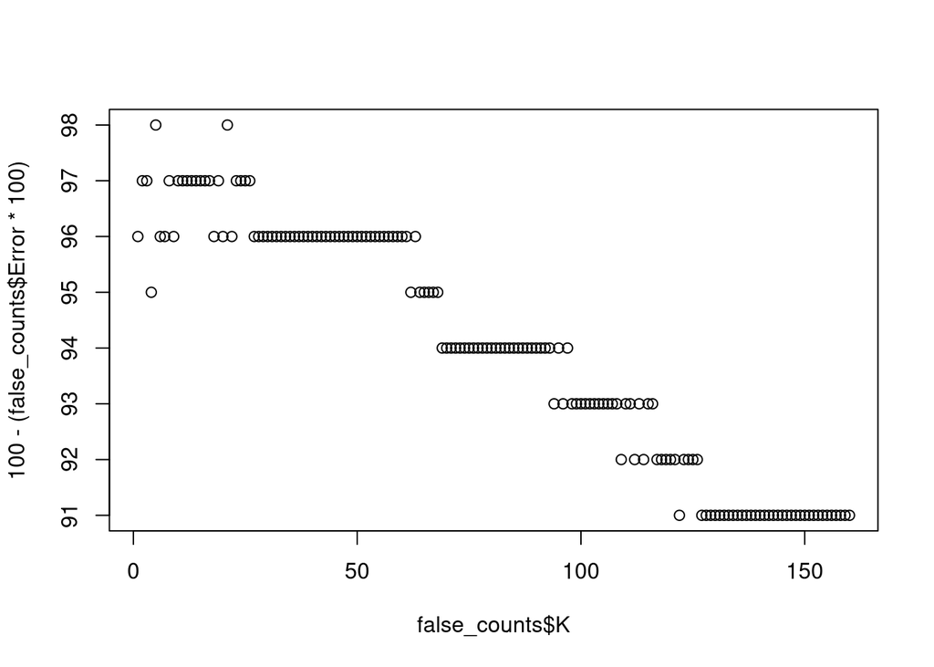

```r
plot(false_counts$K, 100 - (false_counts$Error * 100))
```

The model starts to lose its high accuracy alues at around `k=25`, and decreases as `k` increases (an unsurprising result but still worth noting).

##### Type I and Type II errors for models with varying K

To get a visual representation of model performance relative to Type I and Type II errors, let’s plot the number of false positives and false negatives for each k.

First, false positives:

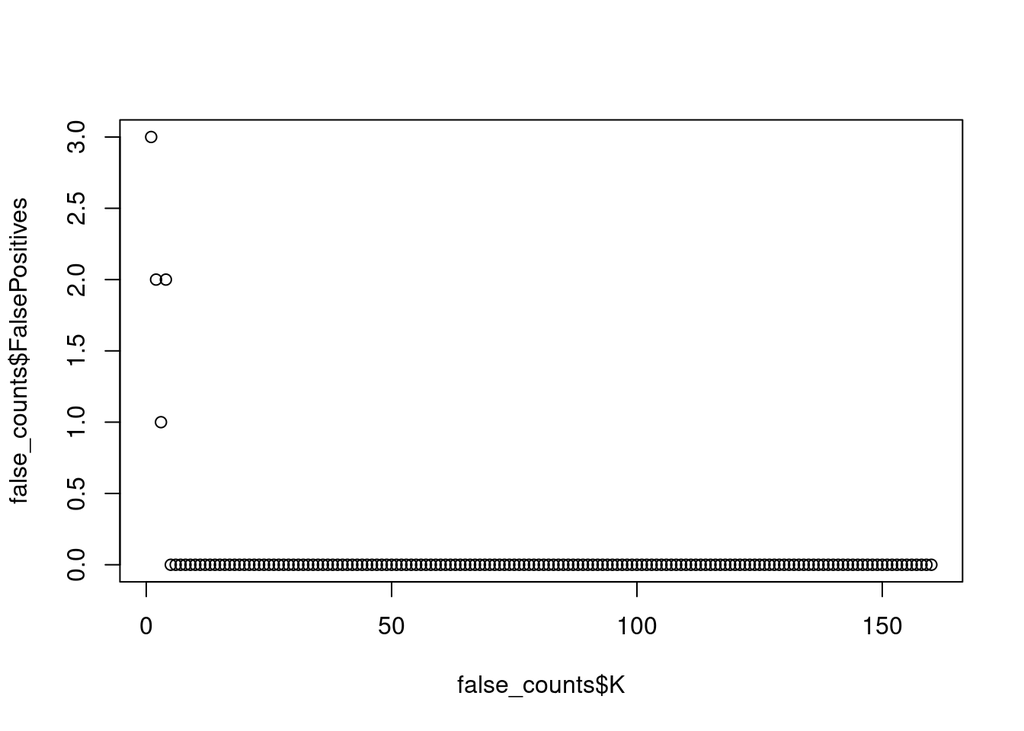

```r
plot(false_counts$K, false_counts$FalsePositives)
```

However, as stated before, false negatives are the results that we are more concerned with. Recall that in actual usage, false negatives are far more dangerous for cancer patients; when a malignant tumor is incorrectly assumed to be benign, the patient will not receive further diagnosis steps and treatment options for a malignant disease which will affect their life expectancy and allow the disease to progress further.

The scatterplot of false negatives for varying k is:

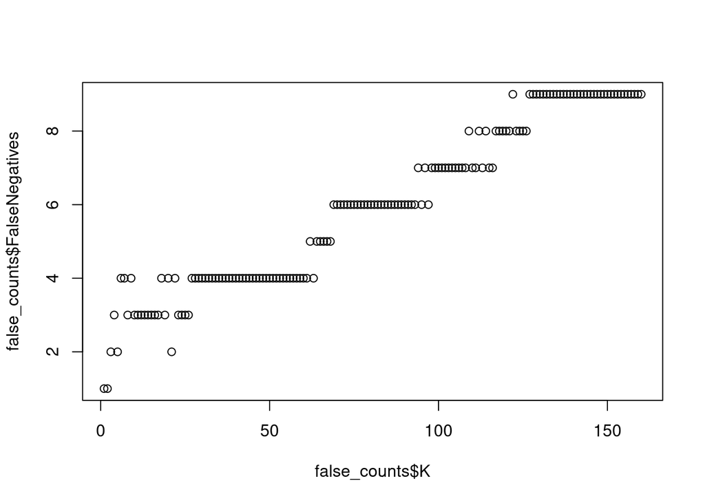

```r
plot(false_counts$K, false_counts$FalseNegatives)
```

Wow! There are way too many false negatives as k increases! Based on this data, the results with a k-value in `[1, 25]` will produce the lowest number of false negatives, which is our preferred outcome.

**These results indicate that smaller values for K lead to lower error rates.**

#### Method 2: Weighted k-NN Model

The library I will be using to explore weighted k-nearest neighbor classification is documented at https://cran.r-project.org/web/packages/kknn/kknn.pdf and requires the `kknn` package in R.

```r
library(kknn)
```

To test the approach, I will generate the same data for the weighted algorithm as I did in the previous section (see Method 1: Testing alternate k-values). This tests the weighted k-NN approach for the same range of k values. **Note:** I have chosen the parameters for the `kknn()` call after some experimentation, so these results are produced after many attempts at optimizing the `kknn` usage.

```r
kknn_false_counts <- data.frame(K=integer(), FalsePositives=integer(), FalseNegatives=integer(), PVal=double(), Error=double())
for (k_val in 1:160) {
  # the fancy new k-knn training method
  wbcd_test_pred <- kknn(wbcd_train_labels~., wbcd_train, wbcd_test, k=k_val, distance = 2, kernel="triangular")
  results <- get_false_tables(wbcd_test_pred$fitted.values)
  chisq_result <- chisq.test(wbcd_test_labels, wbcd_test_pred$fitted.values)
  new_row <- data.frame(K=k_val, FalsePositives=results[[1]], FalseNegatives=results[[2]], PVal=chisq_result$p.value, Error=((results[[1]] + results[[2]]) / 100))
  kknn_false_counts <- rbind(kknn_false_counts, new_row)
}
```

We are looking for an improvement in the false negatives values in this model; the false negatives are plotted here:

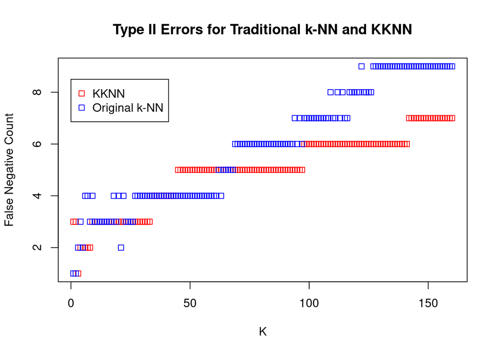

```r
plot(kknn_false_counts$K, kknn_false_counts$FalseNegatives, col="red", ylim=range(c(kknn_false_counts$FalseNegatives, false_counts$FalseNegatives)), xlab="K", ylab="False Negative Count", main="Type II Errors for Traditional k-NN and KKNN", pch=0)
par(new=TRUE)
plot(false_counts$K, false_counts$FalseNegatives, col="blue", axes=FALSE, xlab="", ylab="", pch=0)
legend(0, 8.5, c("KKNN", "Original k-NN"), col=c("red", "blue"), pch=0)
```

What about the model’s accuracy across all k values?

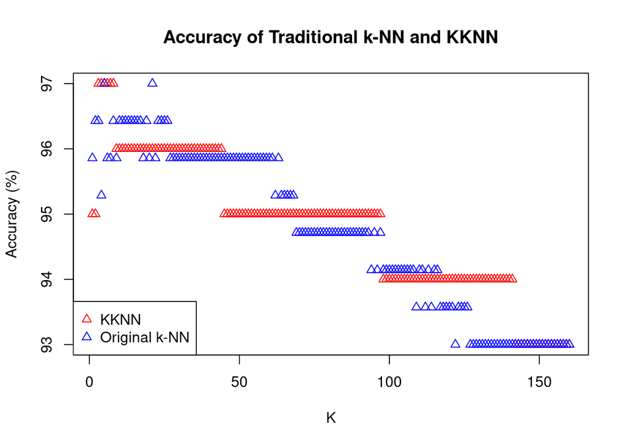

```r
plot(kknn_false_counts$K, 100 - (kknn_false_counts$Error * 100), pch=2, col="red", xlab="K", ylab="Accuracy (%)", main="Accuracy of Traditional k-NN and KKNN")
par(new=TRUE)
plot(false_counts$K, 100 - (false_counts$Error * 100), pch=2, col="blue", axes=FALSE, xlab="", ylab="")
legend("bottomleft", c("KKNN", "Original k-NN"), col=c("red", "blue"), pch=2)
```